# Лабораторная работа №4

Подготовка экспериментального стенда GNS3

Лисовская А.В.

Российский университет дружбы народов, Москва, Россия

14 декабря 2025

## Докладчик

- Лисовская Арина Валерьевна
- Студент, НПИбд01-23
- Российский университет дружбы народов
- 1132231434@pfur.ru

## Цель работы

Установка и настройка GNS3 и сопутствующего программного обеспечения для эмуляции компьютерных сетей. Изучение принципов работы виртуальной среды и импорт образов сетевых устройств.

## Задание

1. Установить пакет GNS3-all-in-one и виртуальную машину GNS3 VM.
2. Настроить параметры виртуализации и сетевого взаимодействия в VirtualBox.
3. Выполнить интеграцию клиента GNS3 с сервером.
4. Импортировать и настроить шаблоны маршрутизаторов FRR и VyOS.

## Установка GNS3 через Chocolatey

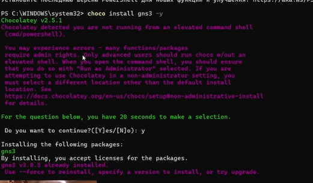

Установка GNS3

## Импорт образа GNS3 VM

Начальный этап установки виртуальной машины GNS3. Выполняется импорт скачанного OVA-файла образа в VirtualBox для подготовки виртуальной среды.

[figure not shown]

Импорт конфигураций в VirtualBox

## Настройка системных параметров VM

В настройках виртуальной машины выделяется 4096 МБ оперативной памяти и выбирается чипсет PIIX3 для обеспечения стабильной работы GNS3 VM.

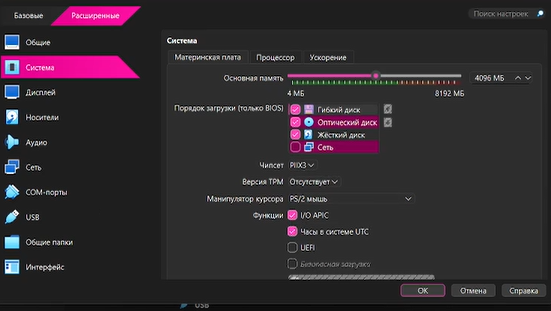

Выделение ОЗУ и настройка чипсета

## Включение вложенной виртуализации

Активация опции Nested VT-x/AMD-V в настройках процессора. Это критически важный шаг для запуска других виртуальных машин и эмуляторов (например, QEMU) внутри GNS3 VM.

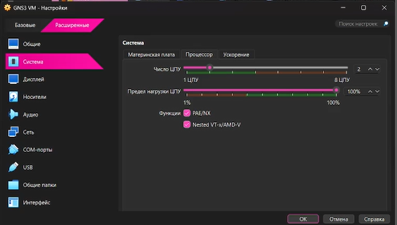

Настройка вложенной виртуализации

## Сетевой адаптер Host-Only

Настройка сетевого адаптера №1 в режиме «Виртуальный адаптер хоста». Это создает приватную сеть между физическим ПК и виртуальной машиной для управления GNS3.

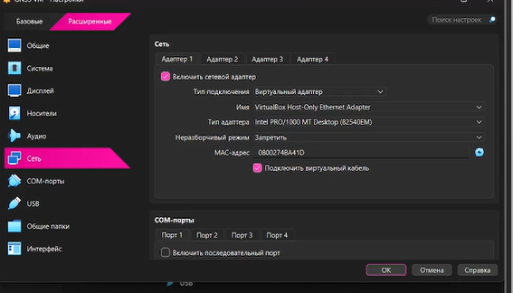

Настройка сети Host-Only

## Параметры Host-Only сети

[figure not shown]

Менеджер сетей хоста VirtualBox

## Настройка DHCP-сервера

[figure not shown]

Настройка диапазона DHCP

## Запущенная консоль GNS3 VM

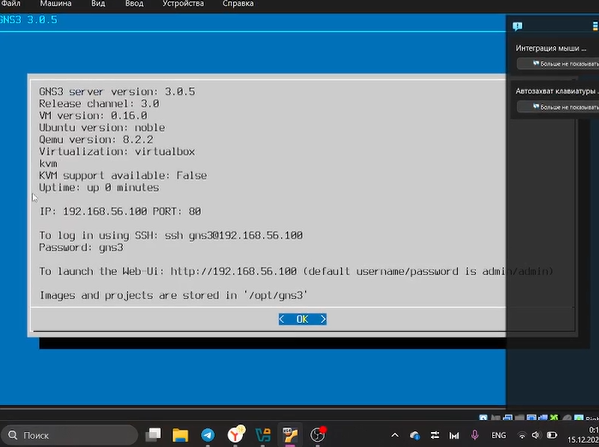

Информационное окно GNS3 VM

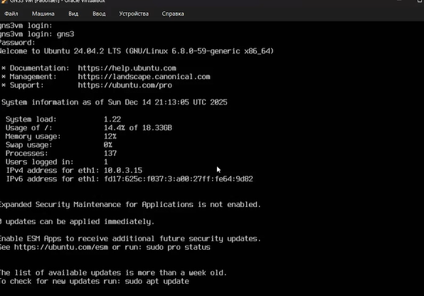

## Настройка удаленного контроллера

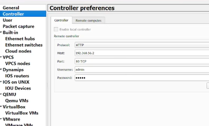

Связь клиента и сервера

## Консольное приложение по умолчанию

Выбор внешнего Telnet-клиента (puffy_standalone.exe) для работы с консолями эмулируемых сетевых устройств (маршрутизаторов и коммутаторов).

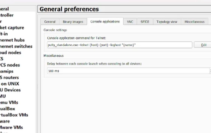

Настройка Console applications

## Выбор шаблона FRR

Начало процесса добавления образа маршрутизатора FRR (FRRouting Project). Пользователь инициирует создание нового шаблона через мастер GNS3.

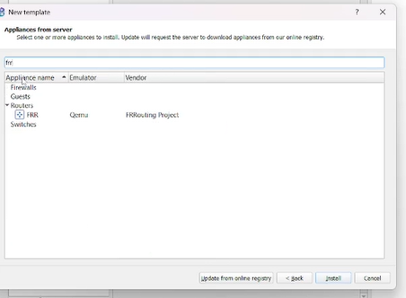

Добавление маршрутизатора FRR

## Выбор версии образа FRR

Выбор конкретной версии программного обеспечения. Версия 8.2.2 помечена как готовая к установке, так как её файлы найдены на контроллере.

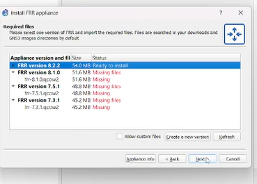

Готовность файлов версии 8.2.2

## Параметры шаблона FRR

Настройка вычислительных ресурсов (256 МБ ОЗУ, 1 vCPU) и установка параметра корректного выключения через сигнал ACPI при закрытии проекта.

[figure not shown]

Общие настройки устройства FRR

## Настройка диска для FRR

Указание образа HDD и активация опции автоматического создания config-диска для сохранения конфигураций маршрутизатора между сессиями.

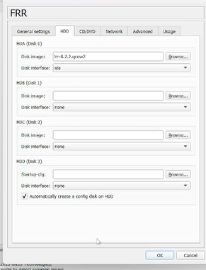

Настройка виртуального жесткого диска

## Подготовка образа VyOS

Выбор и проверка файлов для второго маршрутизатора — VyOS Universal Router версии 1.3.3. Файл образа qcow2 успешно найден в системе.

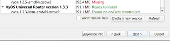

Выбор версии VyOS 1.3.3

## Импорт файлов VyOS

Промежуточный технический этап загрузки и импорта необходимых файлов (vyos-1.3.3-tvm-amd64.qcow2 и empty8G.qcow2) в библиотеку GNS3.

[figure not shown]

## Параметры ресурсов VyOS

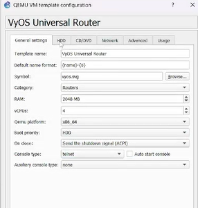

Настройка ресурсов шаблона VyOS

## Настройка диска для VyOS

Завершающий этап настройки хранилища. Включение автоматического создания config-диска для обеспечения постоянства настроек сетевой ОС.

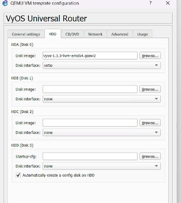

Финальная настройка HDD VyOS

## Выводы

- Приобретены навыки установки и развертывания среды эмуляции GNS3.
- Изучены основы настройки вложенной виртуализации и сетевых адаптеров в VirtualBox.
- Освоены методы интеграции клиента с GNS3 VM и импорта образов сетевых ОС (FRR, VyOS).
- Создана база для дальнейшего проектирования и тестирования сложных сетевых топологий.